# Machine Learning For Signal Processing (ENGR-E 511) Homework 1 , Spring 2022

**Name: Anitha Ganapathy**  
**Email: aganapa@iu.edu**

## **P1: MLE for uniform distribution [3 points]**

Data samples:  
[92, 95.8, 91.3, 94.1, 90.9]

Assuming that the pdf of a uniform distribution can be defined as follow:
$$ p(x)=\left\{\begin{array}{cl} \frac{1}{b-a} & \text { if } a \leq x \leq b \\ 0 & \text { otherwise } \end{array}\right.$$

Note:

- A uniform distribution is a probability distribution in which every value between an interval from a to b is equally likely to be chosen.

### *Estimate the parameters b and a that maximize the likelihood of observing the five data samples you collected.*

- Step 1: Write the likelihood function.
  $$\mathscr{L}(a,b) = \prod_{i=1}^{n}f(x_i;a,b) = \prod_{i=1}^{n}\frac{1}{b-a} = \frac{1}{(b-a)^n}$$

*Here our goal is to find the parameters a and b that maximizes the likelihood of observing the five data samples.*

We know that the condition that should satisfy,
$$a <= min(X_1,X_2,.....X_n)$$ $$b >= max(X_1,X_2,.......X_n)$$

- Step 2: We list the log-likelihood function.

$$\log\mathscr{L}(a,b) = \log\prod_{i=1}^{n}f(x_i;a,b) = \log\prod_{i=1}^{n}\frac{1}{b-a} = log((b-a)^{-n}) = -n * log(b-a)$$

- Step 3: Partially derivating the function with respect to a and b,

$$\frac{\partial }{\partial a} log \mathscr{L}(a,b) = \frac{n}{b-a}$$$$\frac{\partial }{\partial b} log \mathscr{L}(a,b) = -\frac{n}{b-a}$$

where n is the number of samples, which is 5 in this case.

- With the given data points we can observe that the function is monotonically increasing and decreasing for a and b respectively.
- We also know that the distribution is bounded between 90.9 and 95.8.
- 90.9 being the minimum value and 95.8 being the maximum value.

Therefore,

$$\hat{a}_{MLE} = 90.9$$$$\hat{b}_{MLE} = 95.8$$

**Conclusion:**

1. Since Prof. K uses rounded up values in integer multiples of 5, the boundaries for A+ should be multiples of 5.
2. Observing the given data samples the minimum score of getting an A+ is 90.9 and the maximum score getting an A+ is 95.8.
3. After the calculation and analysis, we can conclude Prof. K will grade a student with A+if their final score is between 90 and 100.

$$ 90 \leq score \leq 100 $$

- https://www.statology.org/mle-uniform-distribution/

## **P2: Central Limit Theorem [5 points]**

Imports

```python
# Import the necessary libraries

from PIL import Image
import numpy as np
import matplotlib.pyplot as plt
import matplotlib.mlab as mlab

from google.colab import drive

drive.mount('/content/drive')
```

```python
dirpath = '/content/drive/MyDrive/MLSP_data/'
!ls $dirpath
```

```
luddy.jpg  X.mat
```

### Load luddy.jpg as a 3d array

```python
img = Image.open(dirpath+'luddy.jpg')
luddy = np.asarray(img)

print(luddy.shape)
```

```
(3655, 6496, 3)
```

```python
luddy[:,:,0]
```

```
array([[174, 174, 174, ...,  60,  60,  60],
       [173, 173, 173, ...,  61,  60,  60],
       [173, 173, 173, ...,  61,  61,  60],
       ...,
       [ 35,  34,  32, ...,  20,  21,  21],
       [ 36,  36,  34, ...,  28,  29,  30],
       [ 36,  36,  34, ...,  27,  29,  31]], dtype=uint8)
```

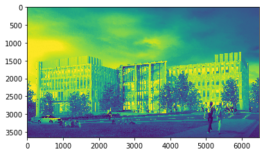

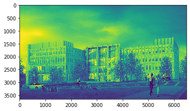

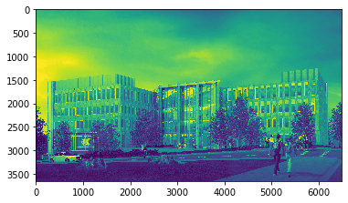

```python
plt.imshow(luddy[:,:,0], interpolation='nearest')
plt.show()

plt.imshow(luddy[:,:,1], interpolation='nearest')
plt.show()

plt.imshow(luddy[:,:,2], interpolation='nearest')
plt.show()
```

```python
import cv2
b, g, r    = cv2.split(luddy) # For BGR image
```

```python
# plt.imshow(b, interpolation='nearest')
# plt.show()

# plt.imshow(g, interpolation='nearest')
# plt.show()

# plt.imshow(r, interpolation='nearest')
# plt.show()
```

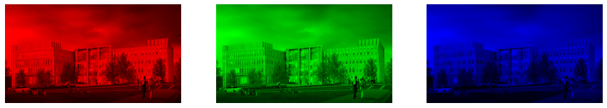

```python
figure, plots = plt.subplots( ncols=3, nrows=1, figsize=(15,15))
for i, subplot in zip(range(3), plots):
    temp = np.zeros(luddy.shape, dtype='uint8')
    temp[:,:,i] = luddy[:,:,i]
    subplot.imshow(temp)
    subplot.set_axis_off()
plt.show()
```

Let’s take the red channel, which will be a matrix of 3655 × 6496 elements.

```python
red_channel = luddy[:,:,0]
red_channel.shape
```

```
(3655, 6496)
```

```python
patch_1 = red_channel[:100, 0:100] # top left corner
patch_2 = red_channel[-100:, -100:]  # bottom right corner
```

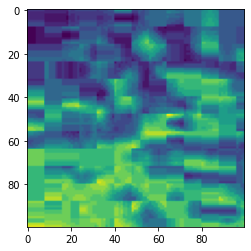

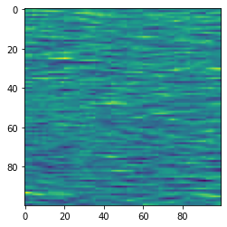

```python
plt.imshow(patch_1)
plt.show()

plt.imshow(patch_2)
plt.show()
```

```python
patch_1.shape, patch_2.shape
```

```
((100, 100), (100, 100))
```

```python
average_patch = (patch_1.flatten() + patch_2.flatten()) / 2
# average_patch = (patch_1 + patch_2) / 2
```

```python
average_patch.shape, patch_1.shape, patch_2.shape
```

```
((10000,), (100, 100), (100, 100))
```

```python
# average_patch[:10] , patch_1[:10], patch_2[:10]
```

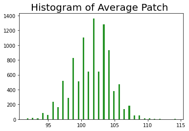

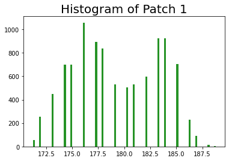

```python
num_bins = 30
plt.title(r'Histogram of Average Patch ', fontsize=20)
plt.hist(average_patch.ravel(), num_bins, facecolor='green', alpha=0.85, rwidth = 0.3)
plt.show()
plt.hist(patch_1.ravel(), num_bins, facecolor='green', alpha=0.85, rwidth = 0.3)
plt.title(r'Histogram of Patch 1', fontsize=20)
plt.show()
```

Now take 100 random patches and repeat the experiment.

```python
red_channel.shape[0] , red_channel.shape[1] , red_channel.shape
```

```
(3655, 6496, (3655, 6496))
```

```python
# n = 1000

# row = np.random.randint(0, red_channel.shape[0] - n)
# col = np.random.randint(0, red_channel.shape[1] - n)
# print("Row = ", row)
# patches = red_channel[row: row+n, row:row+n ]
# plt.imshow(patches)
# plt.show()
```

```python
# Number of samples to average out and print the histogram

def n_patches_histogram(n):
  patches = np.zeros((n, 100, 100))
  for i in range(n):
    row = np.random.randint(0, red_channel.shape[0] - 101)
    temp = red_channel[row: row + 100, row:row + 100 ]
    patches[i] = temp

  # average_patches = np.sum(patches, axis = 0) / n
  average_patches = np.average(patches, axis = 0)
  # print(average_patches.shape)

  num_bins = 30
  print(f"Histogram for {n}x100x100 patches")
  plt.title(r'Histogram of Average of Patch  ', fontsize=20)
  plt.hist(average_patches, bins =num_bins, alpha=0.85, facecolor='green')
  # plt.hist(average_patches.ravel(), bins =num_bins, facecolor='green', alpha=0.7,rwidth=0.3)
  plt.show()
  return average_patches
```

### **Averaged patches for n = 2**

```
Histogram for 2x100x100 patches
```

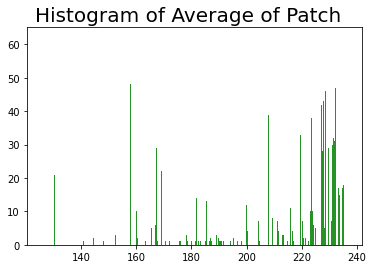

```python
average_2 = n_patches_histogram(2)
```

### **Averaged patches for n = 100**

```
Histogram for 100x100x100 patches
```

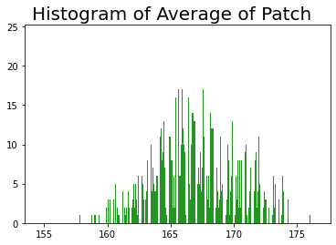

```python
average_100 = n_patches_histogram(100)
```

### **Averaged patches for n = 1000**

```
Histogram for 1000x100x100 patches
```

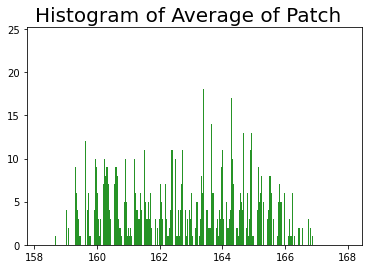

```python
average_1000 = n_patches_histogram(1000)
```

```python
# testing codes

# # n_patches_histogram(100)
# a = np.zeros((3, 3, 3))
# a[0] = [[14,14,14], [2,2,2], [3,3,3]]
# a[1] = [[1,1,1], [2,2,2], [3,3,3]]
# a[2] = [[1,1,1], [2,2,2], [3,3,3]]

# p = np.sum(a, axis=0)
# print(p)
# print(p/3)


# p = np.average(a, axis=0)
# print(p)
# # print(p/3)
```

```python
average_2.shape , average_100.shape, average_1000.shape
```

```
((100, 100), (100, 100), (100, 100))
```

```python
average_2_vector = average_2.flatten()
average_100_vector = average_100.flatten()
average_1000_vector = average_1000.flatten()

average_2_vector.shape , average_100_vector.shape, average_1000_vector.shape
```

```
((10000,), (10000,), (10000,))
```

```python
mean_2 = np.mean(average_2_vector)
variance_2 = np.var(average_2_vector)
std_2 = np.std(average_2_vector)

mean_100 = np.mean(average_100_vector)
variance_100 = np.var(average_100_vector)
std_100 = np.std(average_100_vector)

mean_1000 = np.mean(average_1000_vector)
variance_1000 = np.var(average_1000_vector)
std_1000 = np.std(average_1000_vector)

print("Gaussian parameters for 2 samples :")
print(f'Mean: {mean_2}, Variance: {variance_2}, Std: {std_2}')
print("\n")
print("Gaussian parameters for 100 samples :")
print(f'Mean: {mean_100}, Variance: {variance_100}, Std: {std_100}')
print("\n")
print("Gaussian parameters for 1000 samples :")
print(f'Mean: {mean_1000}, Variance: {variance_1000}, Std: {std_1000}')
```

```
Gaussian parameters for 2 samples :
Mean: 210.4247, Variance: 749.89017991, Std: 27.38412277050335


Gaussian parameters for 100 samples :
Mean: 166.794727, Variance: 10.401505185471, Std: 3.225136459976694


Gaussian parameters for 1000 samples :
Mean: 162.78219009999998, Variance: 4.18407176076199, Std: 2.0455003692891354
```

**The probability density for the Gaussian distribution is**

$$ p(x)=\frac{1}{\sqrt{2 \pi \sigma^{2}}} e^{-\frac{(x-\mu)^{2}}{2 \sigma^{2}}} $$$$ f_{X}\left(x_{j}\right)=\left(2 \pi \sigma_{0}^{2}\right)^{-1 / 2} \exp \left(-\frac{1}{2} \frac{\left(x_{j}-\mu_{0}\right)^{2}}{\sigma_{0}^{2}}\right) $$

**The log-likelihood function is**

$$ l\left(\mu, \sigma^{2} ; x_{1}, \ldots, x_{n}\right)=-\frac{n}{2} \ln (2 \pi)-\frac{n}{2} \ln \left(\sigma^{2}\right)-\frac{1}{2 \sigma^{2}} \sum_{j=1}^{n}\left(x_{j}-\mu\right)^{2} $$

**The negative log-likelihood function,**

$$ l\left(\mu, \sigma^{2}\right)=\frac{n}{2} \ln (2 \pi)+\frac{n}{2} \ln \left(\sigma^{2}\right)+\sum_{i=1}^{n} \frac{(x i-\mu)^{2}}{2 \sigma^{2}} $$

```python
import math

def mle_Gaussian_distribution(mean, var, vector, n_patch):
  n = vector.shape[0]
  mle_0 = (n/2*(math.log(2*math.pi) +math.log(var**2))) + np.sum(((vector-mean)**2)/(2 * (var**2)))
  print(f"MLE for {n_patch} patches is {mle_0}" )

  # mle_1 = n*math.log(2*math.pi*(var**2))/2 + np.sum(((vector-mean)**2)/(2 * (var**2)))
  # print(f"MLE for {n_patch} patches is {mle_1}" )

  # mle_2 = np.sum(math.log(2*math.pi*(var**2))/2 + ((vector-mean)**2)/(2 * (var**2)))
  # print(f"MLE for {n_patch} patches is {mle_2}" )
```

```python
mle_Gaussian_distribution(mean_2, variance_2, average_2_vector, 2)
mle_Gaussian_distribution(mean_100, variance_100, average_100_vector, 100)
mle_Gaussian_distribution(mean_1000, variance_1000, average_1000_vector, 1000)
```

```
MLE for 2 patches is 75395.32066525734
MLE for 100 patches is 33089.59024192856
MLE for 1000 patches is 24697.24229536322
```

### Conclusion

The catch here is that we calculate the negative log MLE where we choose to multiply the answer with '-' sign in order to get a positive answer.

### CLT

**Central Limit Theorem Definition** The central limit theorem is often used in conjunction with the law of large numbers, which states that the average of the sample means and standard deviations will come closer to equaling the population mean and standard deviation as the sample size grows, which is extremely useful in accurately predicting the characteristics of populations.

References:

- https://stackoverflow.com/questions/55509041/loglikelihood-of-normal-distribution
- https://stats.stackexchange.com/questions/141870/connection-between-mle-maximum-likelihood-estimation-and-introductory-inferen
- https://www.statlect.com/fundamentals-of-statistics/normal-distribution-maximum-likelihood
- https://math.stackexchange.com/questions/2853070/prove-neg-log-likelihood-for-gaussian-distribution-is-convex-in-mean-and-varian

Negative log of likelyhood from pdf function of a Gaussian distribution

## P3: Gradient Ascent for Eigendecomposition [5 points]

```python
!ls $dirpath
```

```
luddy.jpg  X.mat
```

```python
# Read .mat files in Python

# import h5py
# f = h5py.File(dirpath+'X.mat','r')
# data = f.get('data/variable1')
# mat = np.array(data) # For converting to a NumPy array


import scipy.io
mat = scipy.io.loadmat(dirpath+'X.mat')

# print(mat.keys())
# print(mat.get('X'))

data = np.array(mat.get('X'))
print("Data shape: ",data.shape)
```

```
Data shape:  (2, 1000)
```

```python
type(data)
```

```
numpy.ndarray
```

### Draw a scatter plot using matplotlib.pyplot.scatter

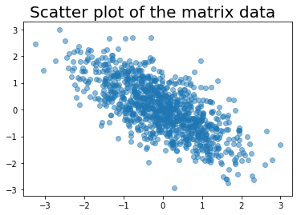

```python
plt.scatter(data[0], data[1], alpha=0.5)
plt.title(r'Scatter plot of the matrix data  ', fontsize=20)
plt.show()
```

The elements of the first eigenvector that you are looking for, w<sup>(1)</sup> ∈ R<sup>2</sup> with random numbers. It should be a vector of two elements, as you have two dimensions in the original data space. Use random samples from a standard normal distribution to initialize them.

The probability density for the Gaussian distribution is

$$ p(x)=\frac{1}{\sqrt{2 \pi \sigma^{2}}} e^{-\frac{(x-\mu)^{2}}{2 \sigma^{2}}} $$

eigenvector - Random vector Initialization

https://www.delftstack.com/howto/numpy/normalize-vector-in-python/

```python
# random samples from a standard normal distribution to initialize them.
eigen_vector = np.random.normal(size=2)
eigen_vector
```

```
array([-0.04563996,  0.74945291])
```

eigenvector - Random vector Normalization  
L2 norm should be 1.

```python
eigen_vector_norm = eigen_vector/np.linalg.norm(eigen_vector)
print(eigen_vector_norm)
```

```
[-0.0607851   0.99815088]
```

```python
# normalized_v = eigen_vector / np.sqrt(np.sum(eigen_vector**2))
# print(normalized_v)
```

Norm of a Vector in Python – Steps for Calculation  
https://www.journaldev.com/45324/norm-of-vector-python

```python
# norm_l1 = np.linalg.norm(eigen_vector_norm, 1)
norm_l2 = np.linalg.norm(eigen_vector_norm, 2)
# print(norm_l1)
print(norm_l2)
```

```
0.9999999999999999
```

```python
w = eigen_vector_norm
w
```

```
array([-0.0607851 ,  0.99815088])
```

Project your data samples to your randomly-initialized-and-then-normalized eigenvector (meaningit’s not quite yet an eigenvector). $$ z=\left(w^{(1)}\right)^{\top} \boldsymbol{X} $$

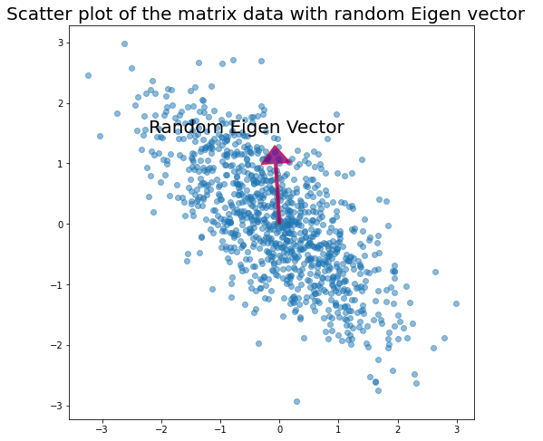

```python
plt.figure(figsize = (8,8))
plt.scatter(data[0], data[1], alpha=0.5)
plt.arrow(0,0,w[0],w[1],head_width = 0.5, head_length = 0.3,facecolor = 'purple', edgecolor= 'red',  width=.05, alpha = 0.8)
plt.annotate("Random Eigen Vector", (w[0]-0.5, w[1]+0.5), alpha =1, horizontalalignment='center', rotation=0, size=20)
plt.title('Scatter plot of the matrix data with random Eigen vector  ', fontsize=20)
plt.show()
```

**Gradient ascent for eigen decomposition**

```python
def gradient_ascent(X, w):
    max_epochs = 10000
    alpha = 0.001

    for epoch in range(max_epochs):
        error = 2 * np.dot(np.dot(X, X.T), w)
        w = w +(alpha * error) # gradient ascent so we are adding in the direction to reach the maxima
        w = w/np.sqrt(np.sum(w**2)) # normalization

    return error, w
```

```python
X = data
eigen_value1, w = gradient_ascent(X, w)
```

```python
print('First Eigen Vector: ' , w)
```

```
First Eigen Vector:  [-0.70593278  0.70827884]
```

```python
temp = np.dot(X, X.T)
temp = np.dot(w.T, temp)
largest_eigen = np.dot(temp, w)
print('Largest Eigen Value: ',largest_eigen)
```

```
Largest Eigen Value:  1658.5883302531925
```

Calculating 's', 'u' and the contribution of the first eigen vector

```python
def svd(w, X):
    s1 = np.sqrt(np.sum(np.dot(w.T,X)**2))
    u1 = np.dot(X.T, w)/s1
    contrib = np.dot(s1,u1.T)
    w, contrib = w.reshape(-1,1), contrib.reshape(-1,1)
    contrib = np.dot(w, contrib.T)
    return s1, u1, contrib
```

```python
s1, u1, contrib = svd(w, X)
```

Subtract the contribution of the first eigen vector from the original matrix.  
subtract the contribution of the first eigenvector, your X won’t have any variation along the direction defined by the first eigenvector.

```python
X.shape, contrib.shape
```

```
((2, 1000), (2, 1000))
```

```python
new_X = X - contrib
print(new_X.shape)
```

```
(2, 1000)
```

Plotting the new data matrix along with the eigen vector

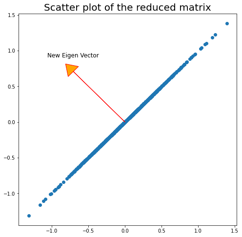

```python
plt.figure(figsize = (8,8))
plt.scatter(new_X[0], new_X[1])
ax = plt.axes()
plt.arrow(0,0,w[0],w[1],head_width = 0.2, head_length = 0.15,facecolor = 'orange', edgecolor= 'red',  width=0, alpha = 1)
plt.annotate("New Eigen Vector", (w[0], w[1]+0.2), alpha =1, horizontalalignment='center', rotation=0, size=12)
plt.title('Scatter plot of the reduced matrix', size=20)
plt.show()
```

Eigenvector associated with the second largest eigenvalue.

```python
w2 = np.random.normal(size = 2)
w2 = w2/np.sqrt(np.sum(w2**2))
print(w2)
```

```
[ 0.79854729 -0.60193208]
```

```python
eigen_vector2, w2 = gradient_ascent(new_X, w2)
print('Second eigen vectors: ',w2)
```

```
Second eigen vectors:  [0.70827884 0.70593278]
```

Scatter plot with 2 eigen values on the actual matrix data

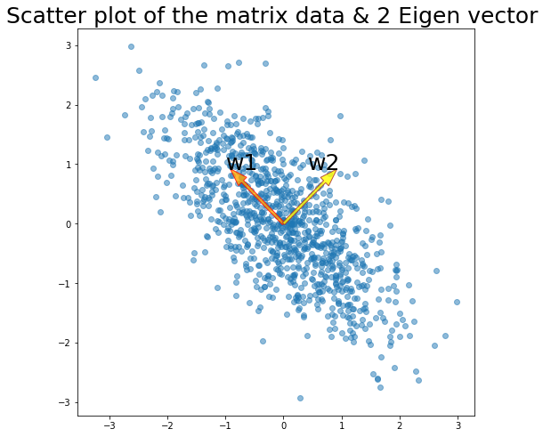

```python
plt.figure(figsize = (8,8))
plt.scatter(data[0], data[1], alpha=0.5)
plt.arrow(0,0,w[0],w[1],head_width = 0.2, head_length = 0.3,facecolor = 'orange', edgecolor= 'red',  width=0.05, alpha = .8)
plt.annotate("w1", (w[0], w[1]+0.2), alpha =1, horizontalalignment='center', rotation=0, size=25)

plt.arrow(0,0,w2[0],w2[1],head_width = 0.2, head_length = 0.3,facecolor = 'yellow', edgecolor= 'brown',  width=0.05, alpha =.8)
plt.annotate("w2", (w2[0], w2[1]+.2), alpha =1, horizontalalignment='center', rotation=0, size=25)
plt.title('Scatter plot of the matrix data & 2 Eigen vector ', fontsize=25)
plt.show()
```

The directions of the two eigenvectors you found, is correct. It is going to be basically looking like two arrows starting from the origin, while pointing to the direction defined by the eigenvectors. They are overlayed on top of the point cloud.

**The 2 Eigen vectors are orthonormal to each other**

## References:

- https://www.statology.org/mle-uniform-distribution/

## Convert the notebook to HTML

```python
# %%shell
# jupyter nbconvert --to html /content/AG_MLSP_SP22_HW_1.ipynb
```